# CMSC320 Final Project

## Group Members: David Fan, Vishal Shenoy

# **Introduction:**

In August, 2012, Valve released a tactical shooter known as Counter-Strike: Global Offensive, CSGO for short. In CSGO, two teams compete in multiple rounds of objective-based game modes. After a team reaches 16 round victories, they have completed their goal and win the entire match. While the concept of the game seems simple, there are a variety of complexities that can make it difficult to determine what the correct strategies and plays each team should make, therefore, in this project, we hope to help define some of the factors that result in a victory or defeat.

# **Part 1: Data collection/curation**

First, we will load the data into our notebook.

All data is found on the kraggle page: https://www.kaggle.com/skihikingkevin/csgo-matchmaking-damage?select=esea_meta_demos.part1.csv

## **Part 1.1:**

The first step in loading in our data is to import all of the libraries we will be using. We will also import libraries that we will need later in the project here.

```python
import pandas as pd
import seaborn as sns
import matplotlib.pyplot as plt
import numpy as np
from sklearn import linear_model

import warnings
warnings.filterwarnings('ignore')
```

## Part **1.2:**

Next, we need to download the CSV file from the kraggle page, upload it into notebook, and finally, give the file path to pandas.

```python
data = pd.read_csv('esea_meta_demos.part1.csv', sep = ',')
data = data.truncate(after = 100014)
data
```

|  | file | map | round | start_seconds | end_seconds | winner_team | winner_side | round_type | ct_eq_val | t_eq_val |
| --- | --- | --- | --- | --- | --- | --- | --- | --- | --- | --- |
| 0 | esea_match_13770997.dem | de_overpass | 1 | 94.30782 | 160.9591 | Hentai Hooligans | Terrorist | PISTOL_ROUND | 4300 | 4250 |
| 1 | esea_match_13770997.dem | de_overpass | 2 | 160.95910 | 279.3998 | Hentai Hooligans | Terrorist | ECO | 6300 | 19400 |
| 2 | esea_match_13770997.dem | de_overpass | 3 | 279.39980 | 341.0084 | Hentai Hooligans | Terrorist | SEMI_ECO | 7650 | 19250 |
| 3 | esea_match_13770997.dem | de_overpass | 4 | 341.00840 | 435.4259 | Hentai Hooligans | Terrorist | NORMAL | 24900 | 23400 |
| 4 | esea_match_13770997.dem | de_overpass | 5 | 435.42590 | 484.2398 | Animal Style | CounterTerrorist | ECO | 5400 | 20550 |
| ... | ... | ... | ... | ... | ... | ... | ... | ... | ... | ... |
| 100010 | esea_match_13785894.dem | de_mirage | 22 | 2236.37600 | 2344.0130 | Team 2 | CounterTerrorist | NORMAL | 31100 | 22000 |
| 100011 | esea_match_13785894.dem | de_mirage | 23 | 2344.01300 | 2421.5300 | Team 1 | Terrorist | NORMAL | 27400 | 24750 |
| 100012 | esea_match_13785894.dem | de_mirage | 24 | 2421.53000 | 2496.6870 | Team 2 | CounterTerrorist | NORMAL | 23950 | 27550 |
| 100013 | esea_match_13785894.dem | de_mirage | 25 | 2496.68700 | 2574.0480 | Team 2 | CounterTerrorist | NORMAL | 25250 | 18500 |
| 100014 | esea_match_13785894.dem | de_mirage | 26 | 2574.04800 | 2658.0860 | Team 2 | CounterTerrorist | SEMI_ECO | 27350 | 11550 |

100015 rows × 10 columns

# **Part 2: Data management and representation**

Let's talk more about what we're looking for in this data. The main conflict in CSGO is between the "Terrorists" and "Counter terrorists". the terrorists try to plant a bomb in one of two locations, and the counter terrorists have to stop them from planting the bomb, or defuse the bomb before it explodes.

An important part of this process is the map that the teams are playing on. CSGO has seven active maps at any given time, and each map has its own traits and features that can end up giving an advantage to either the terrorists or the counter terrorists, meaning map selection and playing "weak side" can be important in the game. We can possibly determine which maps are biased towards the terrorists, and which are biased towards the counter terrorists.

CSGO also has a working economy system. Every match, you get money for a variety of actions, such as scoring kills, winning the round, or planting the bomb. You can then use this money to buy better weapons for the next round. There are a lot of strategies revolving around this, such as forcing out good weapons even though the team cannot afford everything they need, not buying anything for a round in order to save money for future rounds, or simply buying everything that you need. We will look into the effectiveness of these strategies, and determine which strategy works the best overall.

In this case, we can see that there are a few columns that aren't particularly useful to us, specifically, we don't really care about the file name, since we don't have access to that right now anyways, we also do not need the winning team names, since the majority of matches do not have a team name recorded.

We can also replace the winner side with zeroes and ones in order to work better with our code. In our case, we have decided to represent a terrorist win with a zero, and a counter terrorist win with a 1.

```python
data = data.drop('file',1)
data.replace("Terrorist", 0, inplace = True)
data.replace("CounterTerrorist", 1, inplace = True)
data.replace("None", .5, inplace = True)
data['winner_side'] = [int(C) for C in data['winner_side']]

data.head()
```

|  | map | round | start_seconds | end_seconds | winner_team | winner_side | round_type | ct_eq_val | t_eq_val |
| --- | --- | --- | --- | --- | --- | --- | --- | --- | --- |
| 0 | de_overpass | 1 | 94.30782 | 160.9591 | Hentai Hooligans | 0 | PISTOL_ROUND | 4300 | 4250 |
| 1 | de_overpass | 2 | 160.95910 | 279.3998 | Hentai Hooligans | 0 | ECO | 6300 | 19400 |
| 2 | de_overpass | 3 | 279.39980 | 341.0084 | Hentai Hooligans | 0 | SEMI_ECO | 7650 | 19250 |
| 3 | de_overpass | 4 | 341.00840 | 435.4259 | Hentai Hooligans | 0 | NORMAL | 24900 | 23400 |
| 4 | de_overpass | 5 | 435.42590 | 484.2398 | Animal Style | 1 | ECO | 5400 | 20550 |

# **Part 3: Exploratory data analysis**

Now that we have our data, lets try to display it in a way that makes it easier to visualize and focus what we need from the data. For our first graph, we will look for side advantage in maps. We can do this by using a simple seaborn bargraph, which takes in our 'map' column for the x values, and takes the average of the 'winner_side' column for the y values. A value closer to 1 means that the map is more CT sided, a value closer to 0 means the map is more T sided. We can also include a bargraph of the overall winrates in the game, as a control variable.

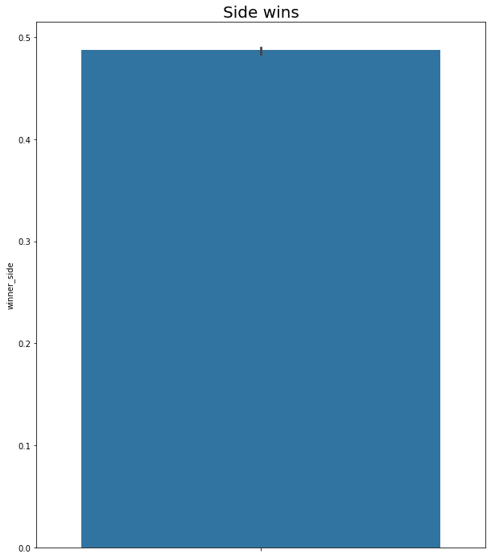

```python
plt.figure(figsize=(10,12))
plt.title('Side wins', fontsize=20)
sns.barplot(y = data['winner_side'])
plt.show()
```

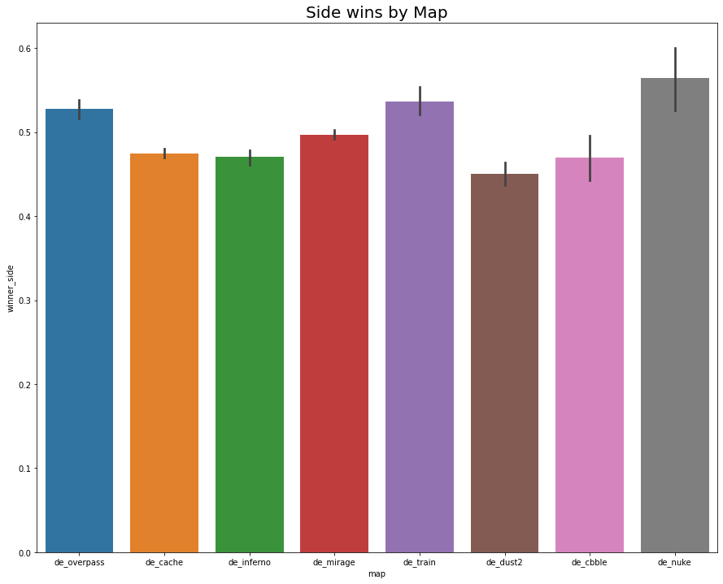

```python
plt.figure(figsize=(15,12))

plt.title('Side wins by Map', fontsize=20)
sns.barplot(x = 'map',y = 'winner_side', data = data)
plt.show()
```

Based on our control graph, we can see that overall, the Terrorists are slightly more likely to win a game compared to the Counter Terrorists.

When looking at our graph based on each individual map, we can see that overpass, train, and nuke are CT sided maps, while cobble, inferno, cache, and dust 2 are T sided, with mirage being pretty much even.

Now let's work on effective economy strategies. There are four basic options for teams looking to buy weapons, they either have enough money and can do a normal buy, they are low on money, but force out weapons even if they cannot afford everything they need, they can semi-eco, and buy cheaper weapons, and save some money, or they can full eco, and buy almost nothing in order to save money. There is also the first round of the game, which is referred to as the pistol round, this round, however, does not offer too many options in terms of strategies so we can ignore it for this part of the project. We want to figure out when each strategy is most effective, In order to do this, we will create a lineplot of winrate based on equity of the teams.

In order to do this, we must first create subsets of our original data, these subsets should each represent a different strategy. After creating each subset, we also must add a new column to represent whether the strategy worked.

Each strategy is also most commonly used in a certain equity range, for example, you wouldn't force buy at over 20000 equity, that would just be a normal buy. Using this knowledge, we can remove any outliers in our data.

```python
df_eco = data[data.round_type == 'ECO']
df_semi = data[data.round_type == 'SEMI_ECO']
df_force = data[data.round_type == 'FORCE_BUY']

to_add = []
lower_eq = []

# organizing relative winning sides on eco rounds
for index, row in df_eco.iterrows():
    if(row['ct_eq_val'] > row['t_eq_val']):
        if(row['winner_side'] == 1):
            to_add.append(0)
        else:
            to_add.append(1)
        lower_eq.append(row['t_eq_val'])

    elif (row['ct_eq_val'] < row['t_eq_val']):
        if(row['winner_side'] == 1):
            to_add.append(1)
        else:
            to_add.append(0)
        lower_eq.append(row['ct_eq_val'])

df_eco['winrate'] = to_add
df_eco['Equity'] = lower_eq

to_add = []
lower_eq = []

# organizing relative winning sides on force rounds
for index, row in df_force.iterrows():
    if(row['ct_eq_val'] > row['t_eq_val']):
        if(row['winner_side'] == 1):
            to_add.append(0)
        else:
            to_add.append(1)
        lower_eq.append(row['t_eq_val'])

    elif (row['ct_eq_val'] < row['t_eq_val']):
        if(row['winner_side'] == 1):
            to_add.append(1)
        else:
            to_add.append(0)
        lower_eq.append(row['ct_eq_val'])

df_force['winrate'] = to_add
df_force['Equity'] = lower_eq

to_add = []
lower_eq = []

# organizing relative winning sides on semi-eco rounds
for index, row in df_semi.iterrows():
    if(row['ct_eq_val'] > row['t_eq_val']):
        if(row['winner_side'] == 1):
            to_add.append(0)
        else:
            to_add.append(1)
        lower_eq.append(row['t_eq_val'])

    elif (row['ct_eq_val'] < row['t_eq_val']):
        if(row['winner_side'] == 1):
            to_add.append(1)
        else:
            to_add.append(0)
        lower_eq.append(row['ct_eq_val'])

df_semi['winrate'] = to_add
df_semi['Equity'] = lower_eq
```

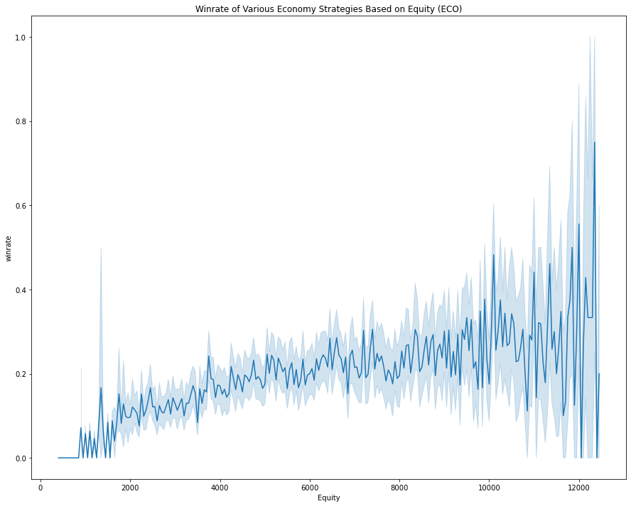

```python
df_eco = df_eco[df_eco.Equity < 12500]

plt.figure(figsize=(15,12))
plt.title("Winrate of Various Economy Strategies Based on Equity (ECO)")

sns.lineplot(data=df_eco, x="Equity", y="winrate")
```

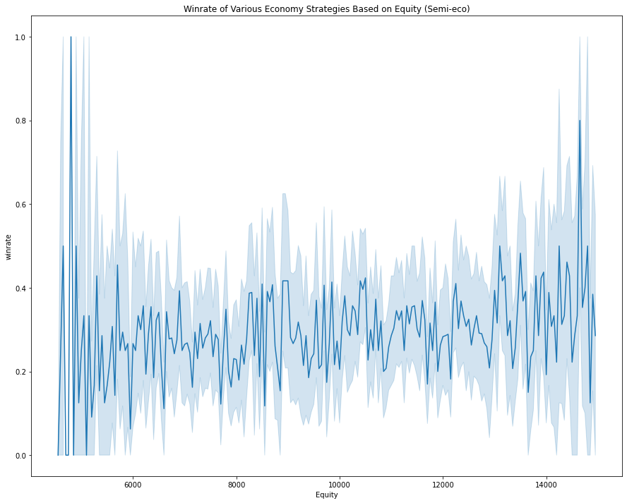

```python
df_semi = df_semi[df_semi.Equity < 15000]
df_semi = df_semi[df_semi.Equity > 4500]

plt.figure(figsize=(15,12))
plt.title("Winrate of Various Economy Strategies Based on Equity (Semi-eco)")

sns.lineplot(data=df_semi, x="Equity", y="winrate")
```

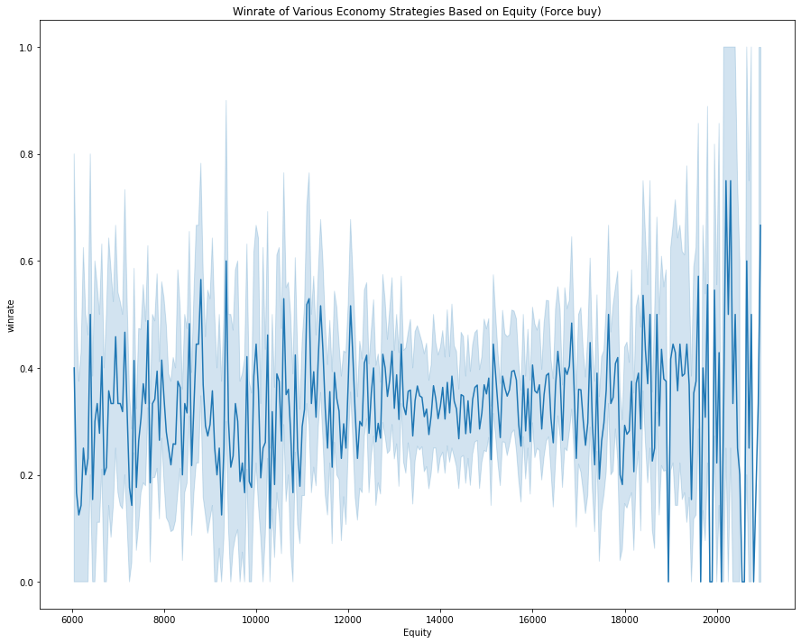

```python
df_force = df_force[df_force.Equity < 21000]
df_force = df_force[df_force.Equity > 6000]

plt.figure(figsize=(15,12))
plt.title("Winrate of Various Economy Strategies Based on Equity (Force buy)")

sns.lineplot(data=df_force, x="Equity", y="winrate")
```

Lets also include a bargraph for overall winrate:

```python
to_add = []
lower_eq = []
temp_data = data.copy()

# organizing overall relative winning side based on equity
for index, row in data.iterrows():
    if((row['round_type'] == 'SEMI_ECO') or (row['round_type'] == 'ECO') or (row['round_type'] == 'FORCE_BUY') ):

        if(row['ct_eq_val'] > row['t_eq_val']):
            if(row['winner_side'] == 1):
                to_add.append(0)
            else:
                to_add.append(1)
            lower_eq.append(row['t_eq_val'])

        else:
            if(row['winner_side'] == 1):
                to_add.append(1)
            else:
                to_add.append(0)
            lower_eq.append(row['ct_eq_val'])

    else:
        to_add.append(.5)
        lower_eq.append(row['ct_eq_val'])

temp_data ['winrate'] = to_add
temp_data ['Equity'] = lower_eq
```

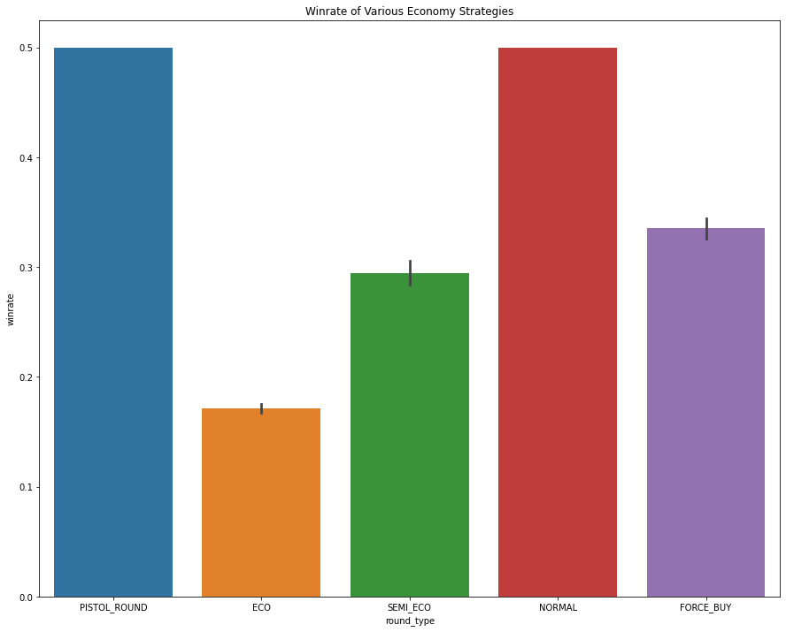

```python
plt.figure(figsize=(15,12))
plt.title("Winrate of Various Economy Strategies")

sns.barplot(data=temp_data , x="round_type", y="winrate")
```

As expected, teams that spend more money in a force buy or semi eco have a higher chance of winning, but we aren't done quite yet. The purpose of running eco and semi eco rounds is to save up money for the next round, therefore, we should also include a winrate graph of the round after.

```python
to_add = []
lower_eq = []
prev = data.iloc[0]

# organizing wins
for index, row in data.iterrows():
    if((prev['round_type'] == 'SEMI_ECO') or (prev['round_type'] == 'ECO') or (prev['round_type'] == 'FORCE_BUY') ):
        to_add.pop()
        lower_eq.pop()

        if(prev['ct_eq_val'] > prev['t_eq_val']):
            if(row['winner_side'] == 1):
                to_add.append(0)
            else:
                to_add.append(1)
            lower_eq.append(prev['t_eq_val'])

        elif (prev['ct_eq_val'] < prev['t_eq_val']):
            if(row['winner_side'] == 1):
                to_add.append(1)
            else:
                to_add.append(0)
            lower_eq.append(prev['ct_eq_val'])

    to_add.append(.5)
    lower_eq.append(prev['ct_eq_val'])
    prev = row


data['winrate'] = to_add
data['Equity'] = lower_eq
```

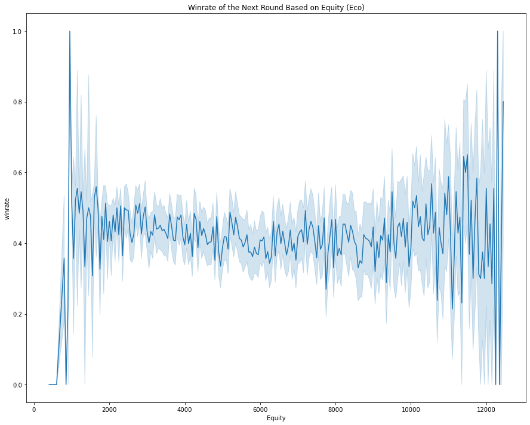

```python
df_Eco = data[data.round_type == 'ECO']
df_Eco = df_Eco[df_Eco.Equity < 12500]


plt.figure(figsize=(15,12))
plt.title("Winrate of the Next Round Based on Equity (Eco)")

sns.lineplot(data=df_Eco, x="Equity", y="winrate")
```

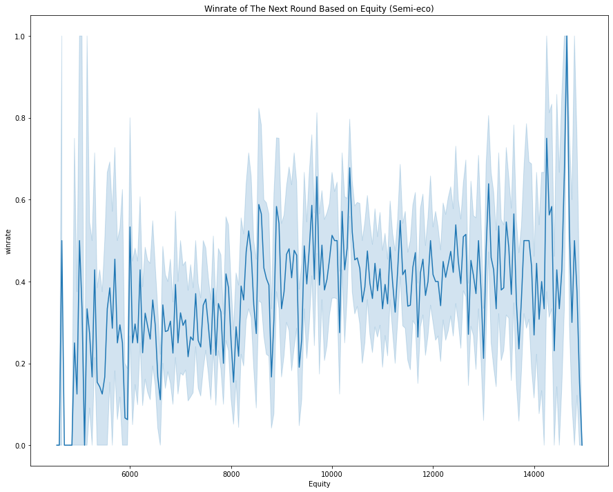

```python
df_semi = data[data.round_type == 'SEMI_ECO']
df_semi = df_semi[df_semi.Equity < 15000]
df_semi = df_semi[df_semi.Equity > 4500]

plt.figure(figsize=(15,12))
plt.title("Winrate of The Next Round Based on Equity (Semi-eco)")

sns.lineplot(data=df_semi, x="Equity", y="winrate")
```

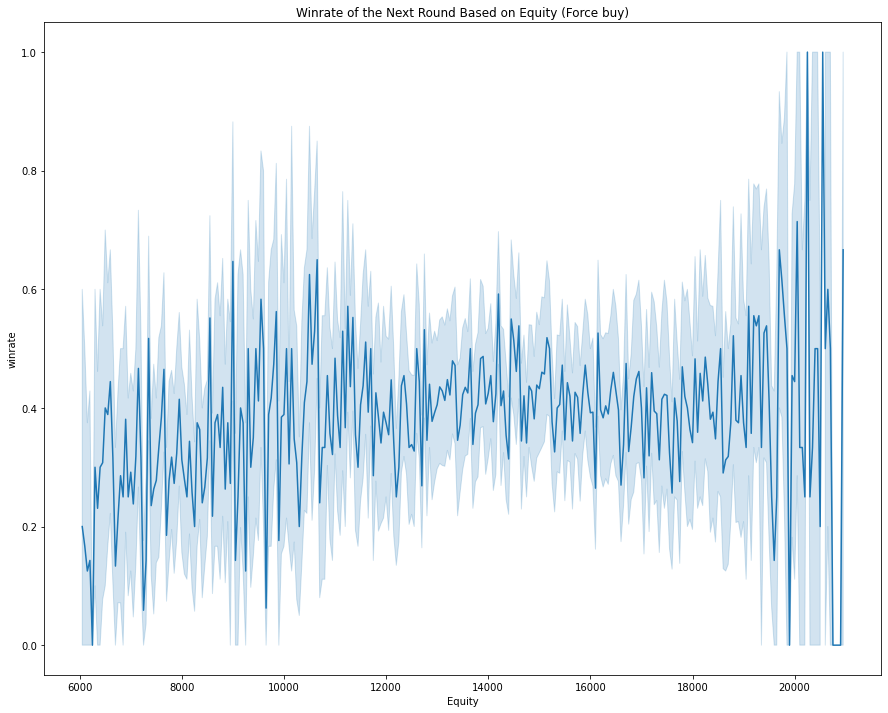

```python
df_force = data[data.round_type == 'FORCE_BUY']
df_force = df_force[df_force.Equity < 21000]
df_force = df_force[df_force.Equity > 6000]

plt.figure(figsize=(15,12))
plt.title("Winrate of the Next Round Based on Equity (Force buy)")

sns.lineplot(data=df_force, x="Equity", y="winrate")
```

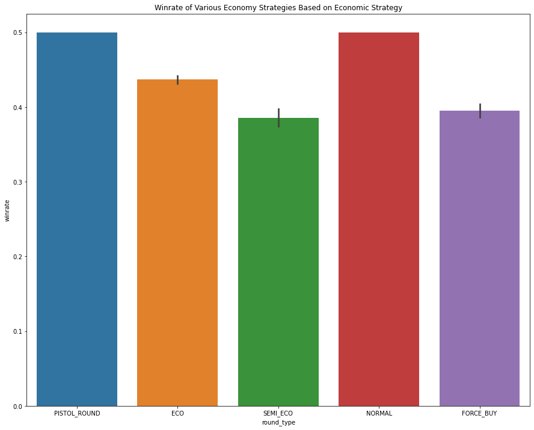

```python
plt.figure(figsize=(15,12))
plt.title("Winrate of Various Economy Strategies Based on Economic Strategy")

sns.barplot(data=data , x="round_type", y="winrate")
```

Now, let's make a lineplot of an average of the winrate of the current round and the next round:

```python
data['winrate'] = (data['winrate'] + temp_data['winrate']) /2
```

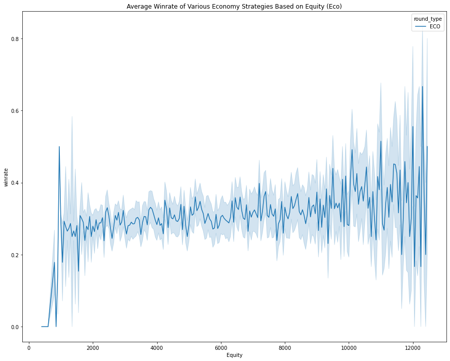

```python
df_Eco = data[data.round_type == 'ECO']
df_Eco = df_Eco[df_Eco.Equity < 12500]


plt.figure(figsize=(15,12))
plt.title("Average Winrate of Various Economy Strategies Based on Equity (Eco)")

sns.lineplot(data=df_Eco, x="Equity", y="winrate",hue = 'round_type')
```

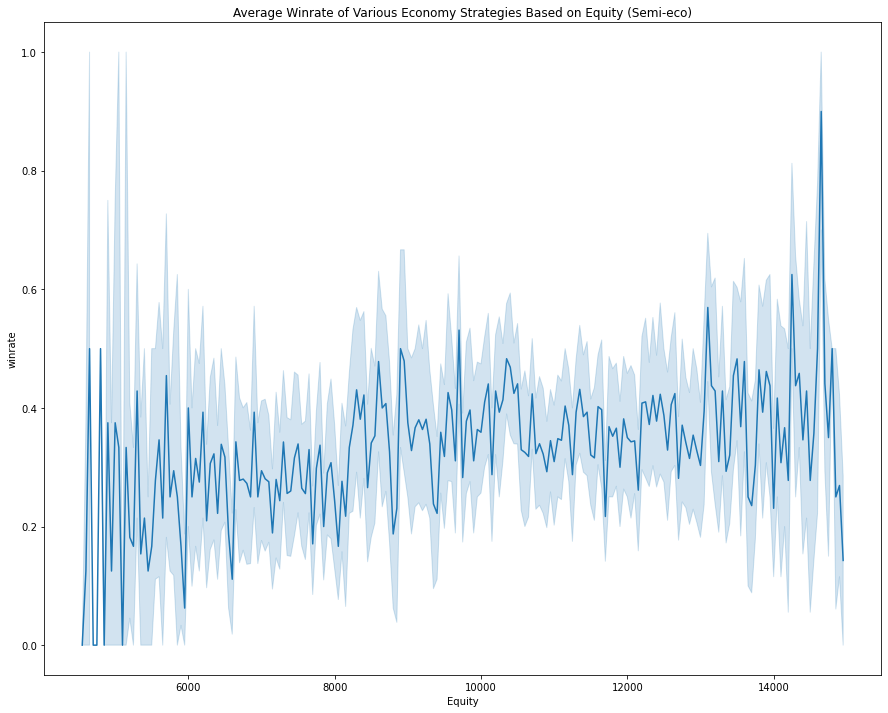

```python
df_semi = data[data.round_type == 'SEMI_ECO']
df_semi = df_semi[df_semi.Equity < 15000]
df_semi = df_semi[df_semi.Equity > 4500]

plt.figure(figsize=(15,12))
plt.title("Average Winrate of Various Economy Strategies Based on Equity (Semi-eco)")

sns.lineplot(data=df_semi, x="Equity", y="winrate")
```

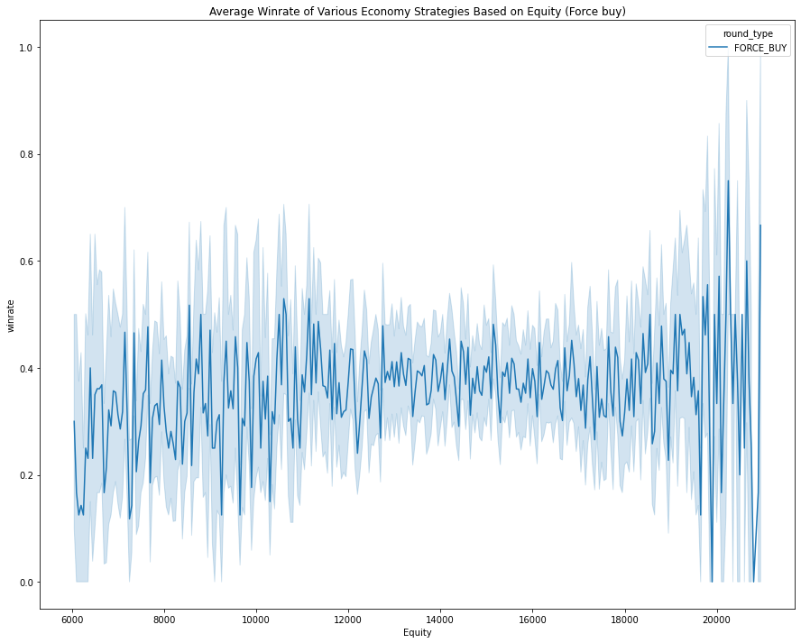

```python
df_force = data[data.round_type == 'FORCE_BUY']
df_force = df_force[df_force.Equity < 21000]
df_force = df_force[df_force.Equity > 6000]

plt.figure(figsize=(15,12))
plt.title("Average Winrate of Various Economy Strategies Based on Equity (Force buy)")

sns.lineplot(data=df_force, x="Equity", y="winrate",hue = 'round_type')
```

Lastly, let's look at the average winrate over both rounds in a bar graph and by map:

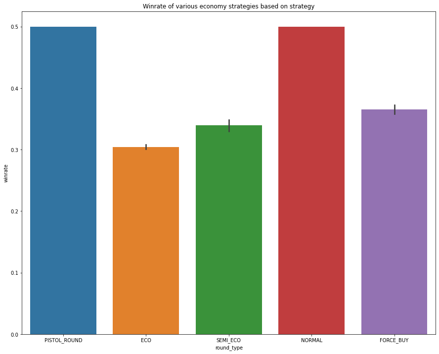

```python
plt.figure(figsize=(15,12))
plt.title("Winrate of various economy strategies based on strategy")

sns.barplot(data=data , x="round_type", y="winrate")
```

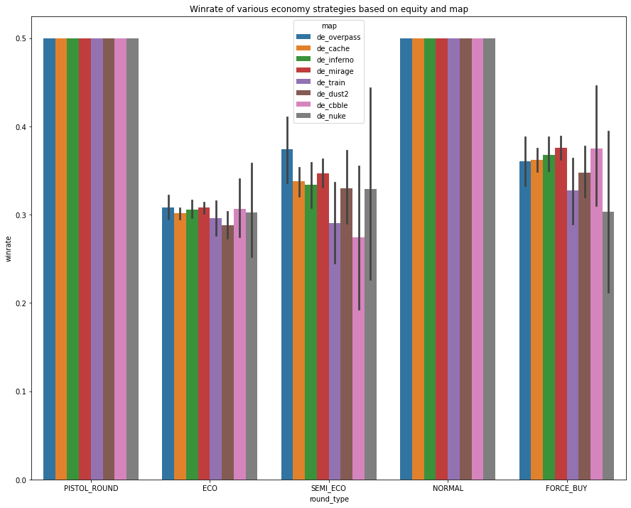

```python
plt.figure(figsize=(15,12))
plt.title("Winrate of various economy strategies based on equity and map")

sns.barplot(data=data , x="round_type", y="winrate",hue = 'map')
```

## **So what do all of these graphs mean?**

We didn't learn too much about the differences in maps when it comes to this data. There weren't any strong correlations or large discrepancies involving it. Maybe the real correlations were the friends we made along the way.

But wait, there's more! We *might* be able to explore the relationship between winrate and equity a little bit more.

# **Part 4: Hypothesis testing**

Despite the fact that some of this data doesn't give way to an interesting analysis, there is no shortage of hypotheses we can produce and test.

For example from the graphs above, we can make a hypothesis that these strategies grow more effective at higher equities. The rates of improvement obviously seem different for each so it would be hard to rank them, but we can do that with adequate testing of our hypothesis and the resulting data.

Let's now graph the same average winrate for each strategy that we did before, but now with a calculated regression line added (provided by scikit learn) for each and see what we get.

```
Linear Regression Model: 7.012872894714383e-06x + (0.2709720235472034)
```

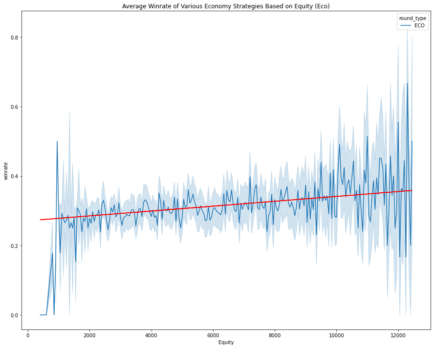

```python
reg = linear_model.LinearRegression()

# data points for regression line
equity_vals = [[x] for x in df_Eco["Equity"].values]
winrate_vals = [[y] for y in df_Eco["winrate"].values]
regfit = reg.fit(equity_vals, winrate_vals)

plt.figure(figsize=(15,12))
plt.title("Average Winrate of Various Economy Strategies Based on Equity (Eco)")

sns.lineplot(data=df_Eco, x="Equity", y="winrate",hue = 'round_type')
plt.plot(equity_vals, regfit.predict(equity_vals), color="red")
print("Linear Regression Model: " + str(reg.coef_[0][0]) + "x + (" + str(reg.intercept_[0]) + ")")
```

```
Linear Regression Model: 1.536017244154552e-05x + (0.18660736990339186)
```

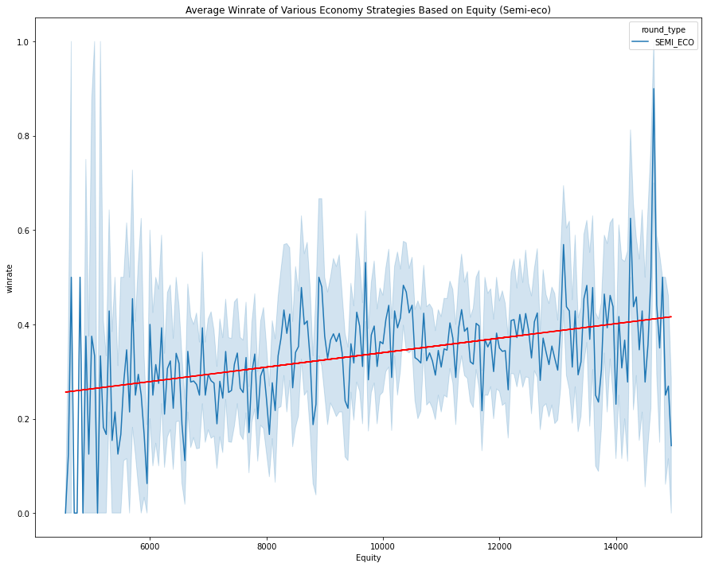

```python
reg = linear_model.LinearRegression()

equity_vals = [[x] for x in df_semi["Equity"].values]
winrate_vals = [[y] for y in df_semi["winrate"].values]
regfit = reg.fit(equity_vals, winrate_vals)

plt.figure(figsize=(15,12))
plt.title("Average Winrate of Various Economy Strategies Based on Equity (Semi-eco)")

sns.lineplot(data=df_semi, x="Equity", y="winrate",hue = 'round_type')
plt.plot(equity_vals, regfit.predict(equity_vals), color="red")
print("Linear Regression Model: " + str(reg.coef_[0][0]) + "x + (" + str(reg.intercept_[0]) + ")")
```

```
Linear Regression Model: 5.414574829360298e-06x + (0.29161267764284365)
```

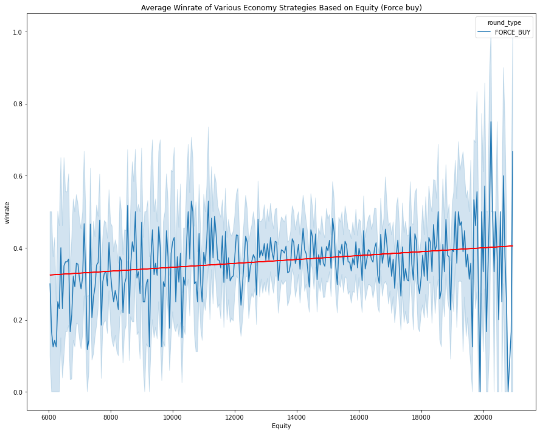

```python
reg = linear_model.LinearRegression()

equity_vals = [[x] for x in df_force["Equity"].values]
winrate_vals = [[y] for y in df_force["winrate"].values]
regfit = reg.fit(equity_vals, winrate_vals)

plt.figure(figsize=(15,12))
plt.title("Average Winrate of Various Economy Strategies Based on Equity (Force buy)")

sns.lineplot(data=df_force, x="Equity", y="winrate",hue = 'round_type')
plt.plot(equity_vals, regfit.predict(equity_vals), color="red")
print("Linear Regression Model: " + str(reg.coef_[0][0]) + "x + (" + str(reg.intercept_[0]) + ")")
```

## **What do these regressions show us?**

Now that we have a mathematical least-squares fit for each strategy, we can come to concrete conclusions regarding our hypothesis for each individual one.

**Eco Rounds:** We can see that eco-buying does increase your winrate by a moderate amount relative to your equity. From the model numbers, winrate odds increase by approximately .7% per $1000 in equity.

**Semi-eco Rounds:** It's clear from the model that the semi-eco strategy has the largest average increase in winrate, and it makes sense if you think about it. At higher equity, you're able to spend a little more during the save round, and still have an adequate full buy the round after, which you cannot do at lower equity amounts. From the model numbers, winrate odds increase by approximately 1.5% per $1000 in equity.

**Force Buy Rounds:** This strategy seems to have the least overall change, especially as you increase your equity. Again, this makes sense since force buying after a certain point would be nearly identical in results, as you expend most of your equity in the current round and still have more than enough to buy again in the next round regardless. From the model numbers, winrate odds increase only by approximately .5% per $1000 in equity. However, it is not statistically honest to say that this is a constant change throughout the entire game, as it due to the stagnation later on.

So, let's retest our hypothesis for force buying, now separating the change in win-rate at lower equity levels versus higher equity levels.

```
Linear Regression Model (Low Equity): 1.3829094429582586e-05x + (0.2069875612666396)
Linear Regression Model (High Equity): -6.080429062842002e-07x + (0.38613221693928695)
```

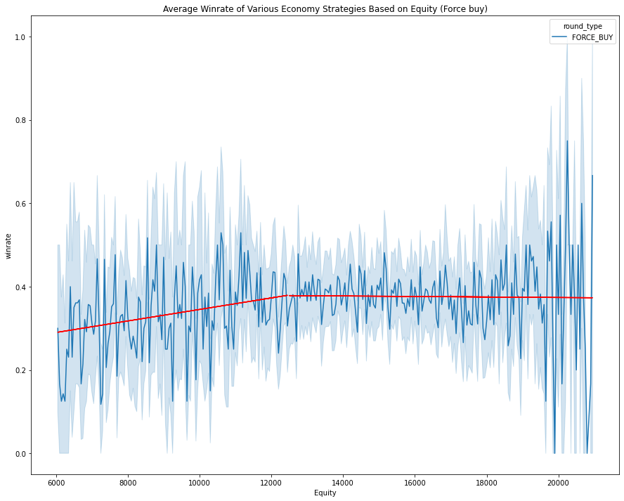

```python
df_force_low = df_force[df_force.Equity < 12500]
df_force_high = df_force[df_force.Equity >= 12500]


plt.figure(figsize=(15,12))
plt.title("Average Winrate of Various Economy Strategies Based on Equity (Force buy)")
sns.lineplot(data=df_force, x="Equity", y="winrate",hue = 'round_type')

reg = linear_model.LinearRegression()

# making two separate regression lines for two different parts of the graph
equity_vals_low = [[x] for x in df_force_low["Equity"].values]
winrate_vals_low = [[y] for y in df_force_low["winrate"].values]
regfit_low = reg.fit(equity_vals_low, winrate_vals_low)
plt.plot(equity_vals_low, regfit_low.predict(equity_vals_low), color="red")

print("Linear Regression Model (Low Equity): " + str(reg.coef_[0][0]) + "x + (" + str(reg.intercept_[0]) + ")")

equity_vals_high = [[x] for x in df_force_high["Equity"].values]
winrate_vals_high = [[y] for y in df_force_high["winrate"].values]
regfit_high = reg.fit(equity_vals_high, winrate_vals_high)
plt.plot(equity_vals_high, regfit_high.predict(equity_vals_high), color="red")

print("Linear Regression Model (High Equity): " + str(reg.coef_[0][0]) + "x + (" + str(reg.intercept_[0]) + ")")
```

Whoa! What we see here is a pretty severe change in results, and it highlights the importance of having context in a valid hypothesis test. Now, we see from the model numbers that with a lower equity amount, your winrate increase jumps to 1.38% per every $1000.

As an additional surprise, we see our first technical negative winrate change with the higher equity model, as it is shown that winrate decreases by .06% per every $1000. However, this is so close to no change that it would be reasonable to claim as stagnant.

# Part 5: Communication of insights

So what have we really done here?

In a way I would write on a resume: we collected, curated, and parsed CS:GO matchmaking data, represented it in a concise and easily parsable table, analyzed the data with graphical representations, and finally developed hypotheses, regressions, and mathematical conclusions from those representations about the intricacies and consequences of certain physical locations and financial decisions within the game.

In a way that I would want a human being to understand what I'm saying: we parsed a messy, large, and unappealing table of data about a video game. We then reorganized the data in a way that was appealing to us and fit our needs of representation in a more appropriate way. The data was then graphed in multiple forms to give us an idea of the trends that take place in the game that we otherwise couldn't deduce, and let us draw certain hypotheses. We then explored the hypotheses we made using linear regression models, adjusting them with proper context, and came to accurate conclusions. In the end we explored and learned more than we ever could just from raw data or gameplay about how maps and the economy within CS:GO works, and which strategies are the most effective at different points.

Global, here I come.